# Phylogeneitc structure variables

## R Markdown

```r
library(toolkitSeqTree)
library(ggtree)
```

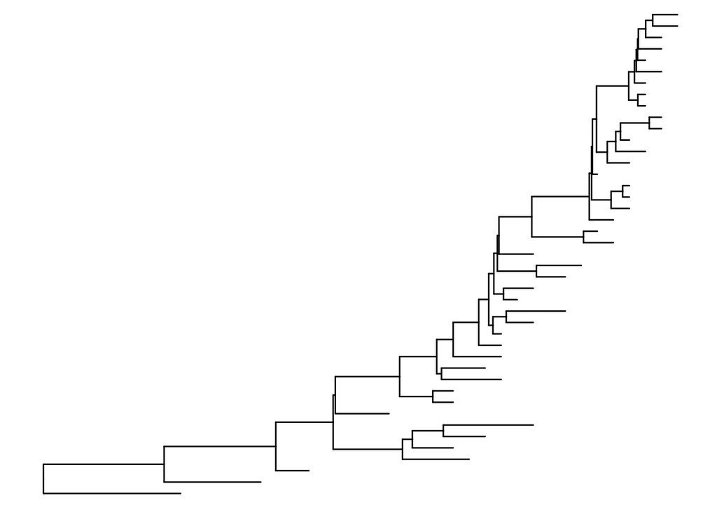

```r
library(ggplot2)
library(dplyr)
tree <- treeio::read.beast('extdata/h1n1_ref_viruses.trees')
tree_dat <- fortify(tree)
ggtree(tree)
```

```r
head(tree_dat)
```

```
## # A tibble: 6 × 10
##   parent  node branch.length label        Control isTip     x     y branch angle
##    <int> <int>         <dbl> <chr>        <chr>   <lgl> <dbl> <dbl>  <dbl> <dbl>
## 1     45     1          6.03 H1N1_A_CHIL… 1       TRUE   13.6     2   10.5  16.7
## 2     48     2          4.16 H1N1_A_JOHA… 2       TRUE   26.6     4   24.5  33.5
## 3     49     3          2.54 H1N1_A_BAYE… 3       TRUE   25.6     5   24.3  41.9
## 4     50     4          2.61 H1N1_A_WELL… 4       TRUE   27.6     6   26.3  50.2
## 5     50     5          5.61 H1N1_A_CHIL… 5       TRUE   30.6     7   27.8  58.6
## 6     53     6          1.27 H1N1_A_BEIJ… 6       TRUE   25.6     9   24.9  75.3
```

The relationships between nodes of the phylogeny are contained in `tree_dat` columns `tree_dat$node` and `tree_dat$parent`. For a bifurcating tree, each internal node of the phylogeny is the parent of two nodes.

The exception to this rule is that the root of the phylogeny is the parent of three nodes including itself, so for the root of the phylogeny, `tree_dat$node == tree_dat$parent`:

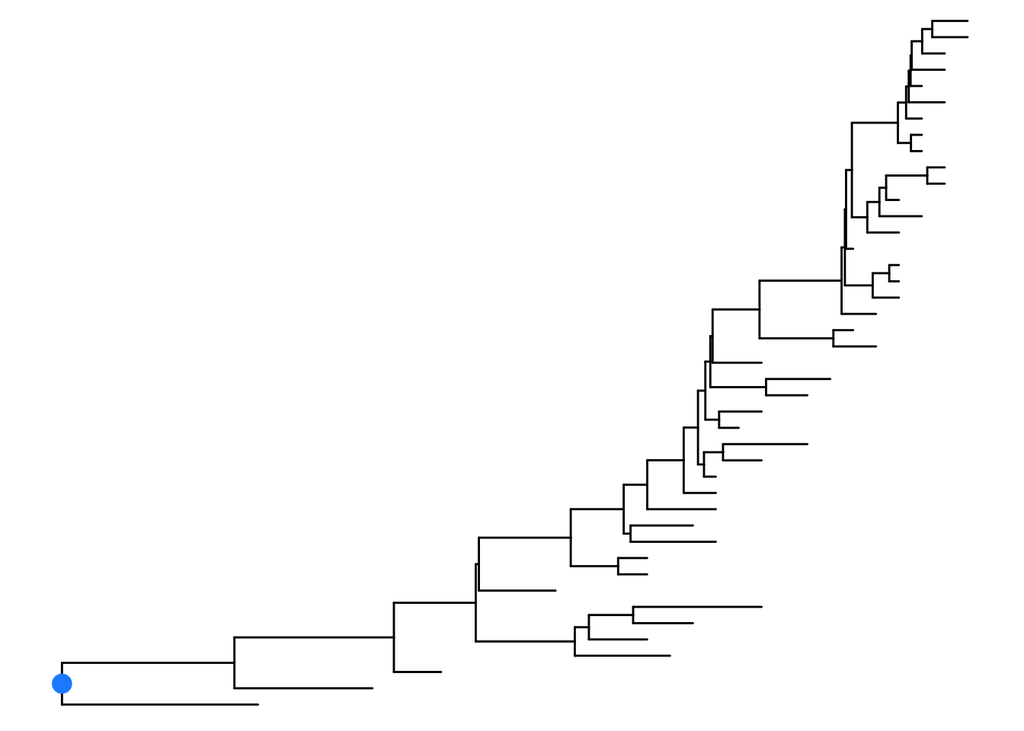

```r
# plot tree with root highlighted
ggtree(tree) +
  geom_point(data = subset(tree_dat, node == parent),
             col = 'dodgerblue', size = 4)
```

### MRCA of two taxa or nodes.

The function `nodes_relationship()` will take two taxa labels (or alternatively two node numbers - which can include internal nodes) and with the argument `relationship = 'mrca'` will identify the node representing their most recent common ancestor (MRCA).

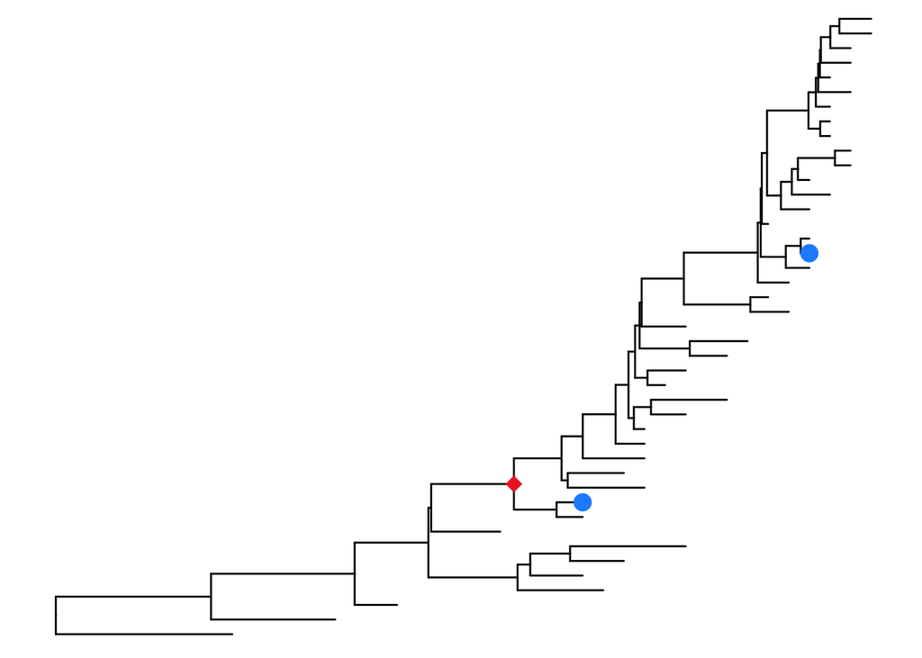

```r
# Pair of taxa of interest are selected and function
taxa_interested <- c('H1N1_A_WUHAN_371_1995',
                     'H1N1_A_FUKUSHIMA_141_2006')
taxa_mrca <- nodes_relationship(tree_dat, taxa = taxa_interested,
                                relationship = 'mrca')

# Highlight taxa_interested as blue circles and MRCA as red diamond
ggtree(tree) +
  geom_point(data = subset(tree_dat, label %in% taxa_interested),
             col = 'dodgerblue', size = 4) +
  geom_point(data = subset(tree_dat, node %in% taxa_mrca),
             col = 'firebrick2', shape = 18, size = 4)
```

### Path between nodes

It may be useful for some analyses to define a path between two nodes (probably between two tips in most cases). The nodes that form this path lie between the two nodes and their MRCA.

This set of nodes (it may be more intuitive to consider the branches) forming this path is identified from the ancestors of the two nodes/taxa identified using `node_ancestors()`. The set forming the path is the set of nodes/branches which are in either of the sets of ancestors, but not their intersection (known as the symmetric difference or disjunctive union of the two sets).

It will usually make sense to complete the path by supplementing this set of nodes with the node/branch connecting the target nodes using the `node_ancestors()` argument `keep_target_node = TRUE`.

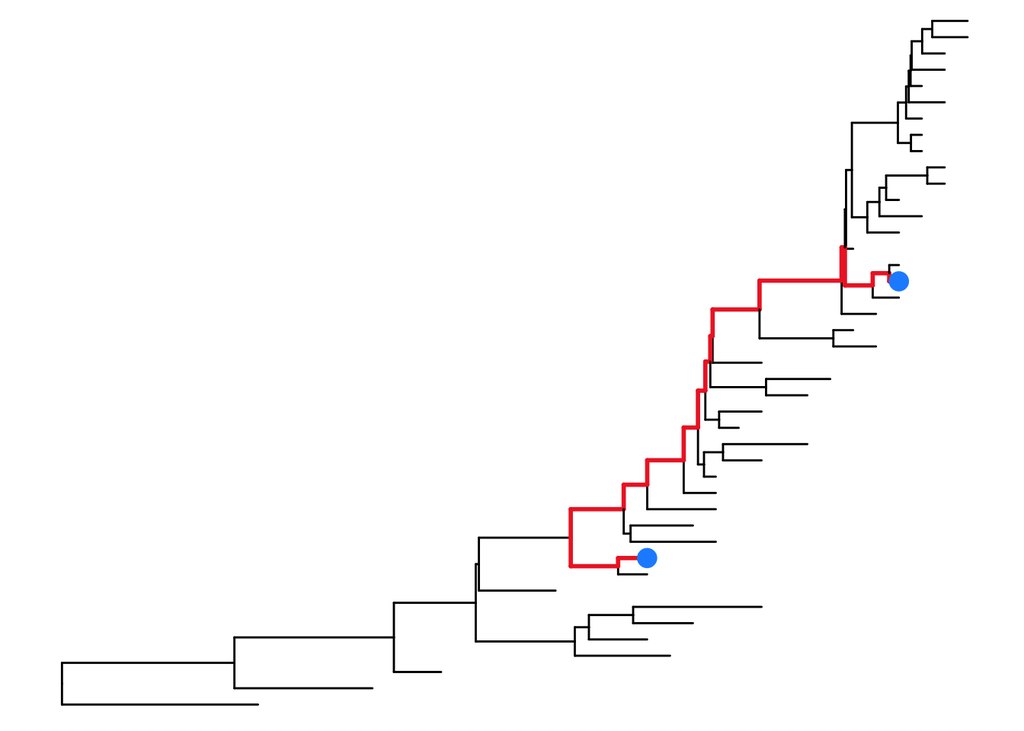

```r
# ID ancestors of two randomly chosen taxa
taxa_interested <- c('H1N1_A_WUHAN_371_1995',
                     'H1N1_A_FUKUSHIMA_141_2006')
ancestors_1 <- node_ancestors(tree_dat, taxa_interested[1],
                              keep_target_node = TRUE)
ancestors_2 <- node_ancestors(tree_dat, taxa_interested[2],
                              keep_target_node = TRUE)

# Nodes in the path between two taxa are identified as the difference
# between the union and the intersect of the two sets of ancestors
path_nodes <- setdiff(union(ancestors_1, ancestors_2),
                      intersect(ancestors_1, ancestors_2))

# Highlight path branches as thicker and red
ggtree(tree, aes(color = node %in% path_nodes,
                 size = node %in% path_nodes)) +
  scale_color_manual(values = c('black', 'firebrick2'), guide = 'none') +
  scale_size_manual(values = c(0.5, 1), guide = 'none') +
  geom_point(data = subset(tree_dat, label %in% taxa_interested),
             col = 'dodgerblue', size = 4)
```

Alternatively, the path between two taxa can be identified using `nodes_relationship()` with the relationship argument set to path (`relationship = 'path'`), which is also the default option.

```r
path_nodes
```

```
##  [1]  7 53 14 68 67 66 65 64 63 62 60 57 56 55 54
```

```r
nodes_relationship(tree_dat, taxa = taxa_interested,
                   relationship = 'path')
```

```
##  [1]  7 53 14 68 67 66 65 64 63 62 60 57 56 55 54
```

## Creating variables

In an analysis exploring variation in some trait associated with a property of each taxa or perhaps measurements that reflect the similarity of taxa. To explore variation in a trait measured per taxa, it may be sensible to use variables representing whether each node/branch exists in the evolutionary history of that taxa (i.e. is the node/branch identified as an ancestor using `node_ancestors()`, or not). To explore variation in a trait measured between pairs of taxa, it may be sensible to to use variables representing whether each node/branch separates the pair in a path drawn through the tree along branches of the phylogeny. Variables of this nature can be classified using `nodes_relationship()` with `relationship = 'path'`.

### Difference variables

Logical variable for each node/branch and whether or not it fals on a path between each pair of taxa. `generate_branch_vars()` generates a column/variable representing each node/branch and a row/observation per combination of taxa.

```r
# generate_branch_vars() will produce
dat <- generate_branch_vars(tree_dat, variable_type = 'difference', prefix = 'branch_')

dat[1:6, 1:6]
```

```
##                       label_1             label_2 branch_1 branch_2 branch_3
## 1         H1N1_A_CHILE_1_1983 H1N1_A_CHILE_1_1983    FALSE    FALSE    FALSE
## 2 H1N1_A_JOHANNESBURG_82_1996 H1N1_A_CHILE_1_1983     TRUE     TRUE    FALSE
## 3        H1N1_A_BAYERN_7_1995 H1N1_A_CHILE_1_1983     TRUE    FALSE     TRUE
## 4    H1N1_A_WELLINGTON_8_1997 H1N1_A_CHILE_1_1983     TRUE    FALSE    FALSE
## 5      H1N1_A_CHILE_4795_2000 H1N1_A_CHILE_1_1983     TRUE    FALSE    FALSE
## 6     H1N1_A_BEIJING_262_1995 H1N1_A_CHILE_1_1983     TRUE    FALSE    FALSE
##   branch_4
## 1    FALSE
## 2    FALSE
## 3    FALSE
## 4     TRUE
## 5    FALSE
## 6    FALSE
```

To get an idea of how these variables look, first select a viewpoint virus then look for a variable for a node/branch. It is then possible to look at which taxa this node/branch fall on the path between them (i.e. diff variable == TRUE)

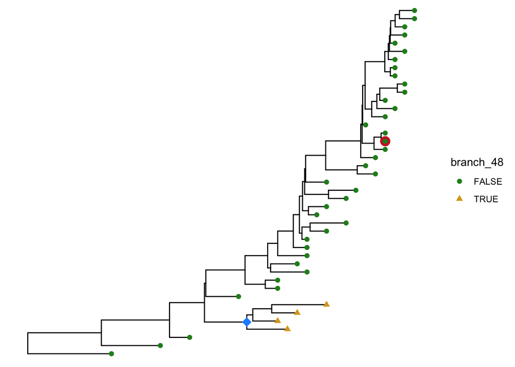

```r
# regenerate clean version of tree_dat
tree_dat <- fortify(tree)

# subset this df do that only one virus is present as 'label_1' then
# left_join() using 'label_2'
taxa_subset <- subset(dat, label_1 == 'H1N1_A_FUKUSHIMA_141_2006')
tree_dat <- left_join(tree_dat, taxa_subset, by = c('label' = 'label_2'))

ggtree(tree) +
  # Viewpoint virus highlighted in red tip node
  geom_point(data = subset(tree_dat,
                           label == 'H1N1_A_FUKUSHIMA_141_2006'),
             col = 'firebrick3', size = 4) +
  # branch/node assoc. variable diff_48 highlighted with blue diamond
  geom_point(data = subset(tree_dat, node == 48),
             col = 'dodgerblue', shape = 18, size = 4) +
  # colour/shape of tip nodes depend on whether the combination of them and
  # the viewpoint virus are separated by the branch
  geom_point(data = subset(tree_dat, isTip == TRUE),
             aes(col = branch_48, shape = branch_48), size = 2) +
  scale_color_manual(values = c('forestgreen', 'goldenrod'))
```

The above plot shows a small clade of viruses that are separated from the taxa labelled `'H1N1_A_FUKUSHIMA_141_2006'` by a branch chosen for this explanation (branch 48) for which `diff_48 == TRUE`. This clade of four viruses are separated from all other viruses in the tree by branch/node 48, therefore if any pair of viruses being compared include one virus in this clade of four and one virus outwith this clade then `diff_48 == TRUE`.